# spring_2

Selam Berekat

6/1/2021

Research Questions:

1. Construct a correlation matrix for all key variables?
2. Plot to show a relationship between all the key variables?

Methods:

1. In order to create a correlation matrix, we first determined the type of variables and checked the proportion of data available in the dataset. And, we created the correlation matrix between all the variables.
2. Plotting according to the variable data type and the finding.

```
##   Union Gravity Ins-Scope Ins-Type Noviol Cur-Penalty Init-Penalty
## 1     Y      NA         B        H  FALSE         150          150
## 2     Y      NA         B        H  FALSE         300          300
## 3     Y      NA         B        H  FALSE         150          150
## 4     Y      NA         B        H  FALSE         150          150
## 5     Y      NA         B        H  FALSE        4500         4500
## 6     Y      NA         B        H  FALSE         150          150
```

```
## [1] "The proportion of missing/removed data for each variables"
```

```
##        Union      Gravity    Ins-Scope     Ins-Type       Noviol  Cur-Penalty
##    0.0000000    0.6724611    0.0000000    0.0000000    0.0000000    0.3549863
## Init-Penalty
##    0.2808783
```

# Interest_1: Correlation matrix

[output not shown]

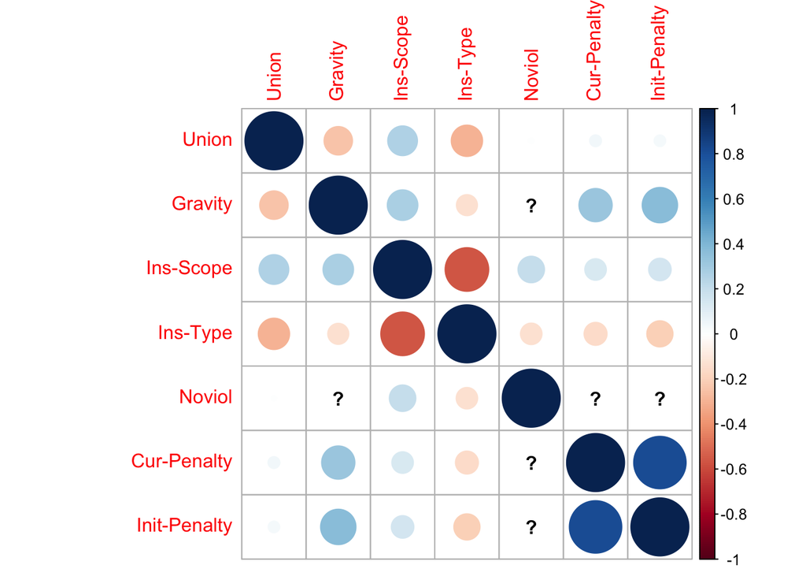

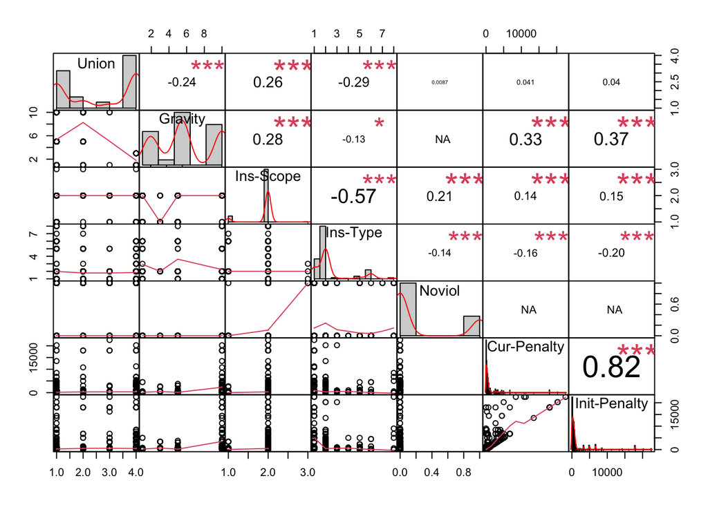

Correlated are: Union vs InsScope and !Gravity and InsType Gravity vs InsScope and Cur-Penalty and Init-Penalty Ins-Scope vs Union, Gravity, Noviol, Cur-Penalty and Init-Penalty, but !Ins-Type etc…

# Interest_2: Plot

```
##   Union InsScope InsType Noviol CurPenalty InitPenalty
## 1     1        2       6      0        150         150
## 2     1        2       6      0        300         300
## 3     1        2       6      0        150         150
## 4     1        2       6      0        150         150
## 5     1        2       6      0       4500        4500
## 6     1        2       6      0        150         150
```

[output not shown]

[output not shown]

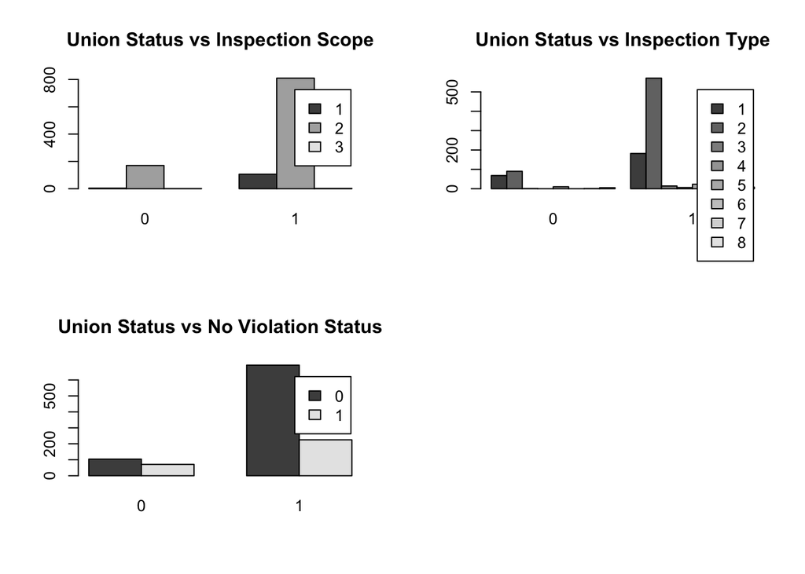

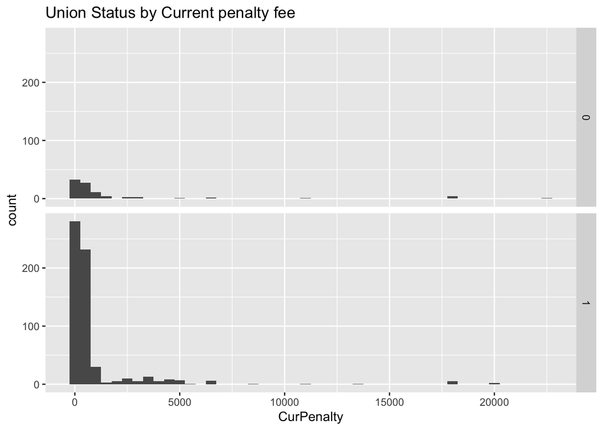

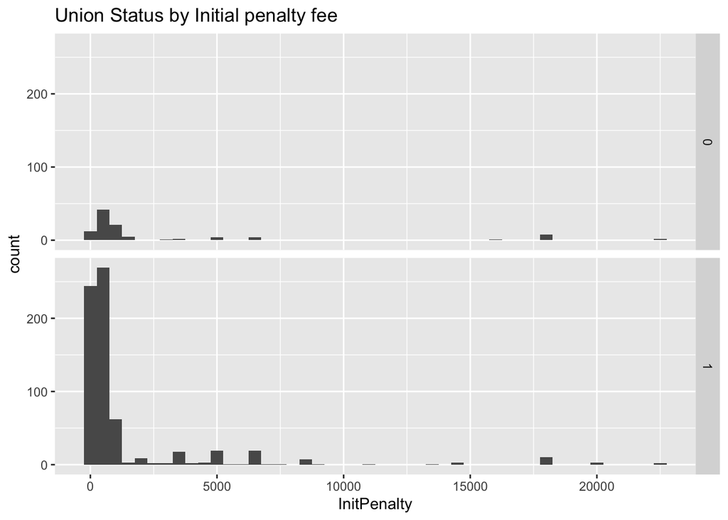

Methods: Data analysis approach using either: Logistic Regression model (applicable for categorical variables), and add data visualization (plots)

Code Appendix:

```r
rm(list=ls())
# Load packages
library(tidyverse)
library(tidyr)
library(ggplot2)
library(corrplot)
osha <- read.csv("dataset.csv", header = T)
y1 <- as.factor(osha$union_status)
x1 <- as.numeric(osha$gravity)
x2 <- as.factor(osha$insp_scope)
x3 <- as.factor(osha$insp_type)
x4 <- osha$noviol

x5 <- as.numeric(osha$current_penalty)
x6 <- as.numeric(osha$initial_penalty)
df <- data.frame(y1, x1, x2, x3, x4, x5, x6)
colnames(df) <- c("Union", "Gravity", "Ins-Scope", "Ins-Type", "Noviol", "Cur-Penalty", "Init-Penalty")
head(df)
paste("The proportion of missing/removed data for each variables")
prop <- apply( apply(df, 2, is.na),  2, sum )/nrow(df) #proportion
prop
paste("Correlation Matrix for all variables except Gravity")

df[] <- lapply(df, as.numeric)
corrplot(cor(df, use = "pairwise.complete.obs"))


library("PerformanceAnalytics")
library(EnvStats)
chart.Correlation(df, histogram = TRUE, pch = 19)
df2 <- data.frame(y1, x2, x3, x4, x5, x6)
colnames(df2) <- c("Union", "InsScope", "InsType", "Noviol", "CurPenalty", "InitPenalty")

##Y1: Union
df2 <- df2 %>% mutate(Union = ifelse((Union == "Y" | Union == "U" | Union == "A"), 1, 0))

##X4: Noviol
df2$Noviol = ifelse(df2$Noviol == "TRUE", 1, 0) #[ 1=True, No Viol and 0=False, Yes Viol ]

##X2: Inspection Scope
df2$InsScope <- factor(df2$InsScope, levels = c("A", "B", "D"),
                       labels = c("1", "2", "3"))

##X3: Inspection Type
df2$InsType <- factor(df2$InsType, levels = c("A", "B", "C", "F", "G", "H", "J", "M"),
                      labels = c("1", "2", "3", "4", "5", "6", "7", "8"))



head(df2)
 table(df2)
library(ggplot2)

par(mfrow=c(2,2))
two.way = table(df2$InsScope, df2$Union)
barplot(two.way, beside = TRUE, legend.text = rownames(two.way), main = "Union Status vs Inspection Scope")

two.way = table(df2$InsType, df2$Union)
barplot(two.way, beside = TRUE, legend.text = rownames(two.way), main = "Union Status vs Inspection Type")

two.way = table(df2$Noviol, df2$Union)
barplot(two.way, beside = TRUE, legend.text = rownames(two.way), main = "Union Status vs No Violation Status")

par(mfrow=c(2,2))
ggplot(df2, aes(x = CurPenalty)) +
  geom_histogram(binwidth = 500) +
  facet_grid(Union ~ .) +
  ggtitle("Union Status by Current penalty fee")

ggplot(df2, aes(x = InitPenalty)) +
  geom_histogram(binwidth = 500) +
  facet_grid(Union ~ .) +
  ggtitle("Union Status by Initial penalty fee")

df2 <- data.frame(y1, x2, x3, x4, x5, x6)
colnames(df2) <- c("Union", "InsScope", "InsType", "Noviol", "CurPenalty", "InitPenalty")

##Y1: Union
df2 <- df2 %>% mutate(Union = ifelse((Union == "Y" | Union == "U" | Union == "A"), 1, 0))

##X4: Noviol
df2$Noviol = ifelse(df2$Noviol == "TRUE", 1, 0) #[ 1=True, No Viol and 0=False, Yes Viol ]

##X2: Inspection Scope
df2$InsScope <- factor(df2$InsScope, levels = c("A", "B", "D"),
                       labels = c("1", "2", "3"))

##X3: Inspection Type
df2$InsType <- factor(df2$InsType, levels = c("A", "B", "C", "F", "G", "H", "J", "M"),
                      labels = c("1", "2", "3", "4", "5", "6", "7", "8"))
# table(df2$Noviol)
```